# Scatterplots

We will show how to create scatterplots of the information in Example 1 using Matplotlib.

Make sure that the order you input the values for the explanatory variable (x) is the same as the response variable (y).

We use the `scatter` method. The first parameter is the list of x-coordinates (explanatory variable); the second parameter is the list of y-coordinates (response variable).

```python
import matplotlib.pyplot as plt
```

```python
age = [2,3,3,2,4,5,6,1,0,4,7]
value = [15,12,13,14,13,10,10.5,16.5,18,14,11]
```

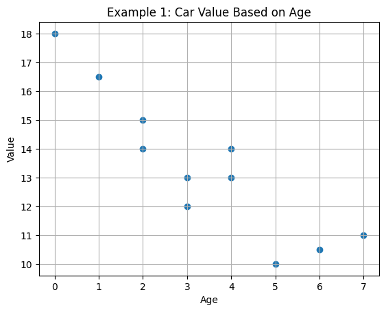

```python
fig, ax = plt.subplots()

ax.scatter(age, value)  # x-axis goes first; y-axis goes next
ax.grid()
ax.set_xlabel("Age")
ax.set_ylabel("Value")
ax.set_title("Example 1: Car Value Based on Age")

plt.show()
```

# Adding Mean Lines for X and Y

We are going to have to import NumPy so it will calculate the means of the x- and y-coordinates.

```python
import numpy as np
```

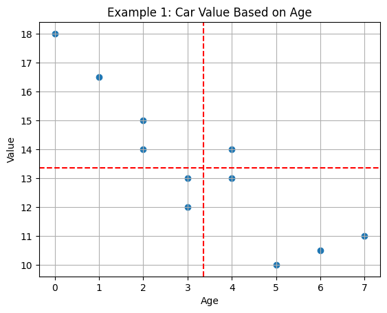

```python
fig, ax = plt.subplots()

ax.scatter(age, value)
# axvline will add a vertical line; axhline will add a horizontal one
ax.axvline(np.mean(age), color = 'red', linestyle = '--')  # linestyle = '--' creates a dashed line
ax.axhline(np.mean(value), color = 'red', linestyle = '--')
ax.grid()
ax.set_xlabel("Age")
ax.set_ylabel("Value")
ax.set_title("Example 1: Car Value Based on Age")

plt.show()
```

# Exercise

A college math class was given a pretest on the first day to assess any prior knowledge of the course. They were given a final exam on the last day of the course.

Create a scatterplot of the pretest and final exam scores data set below with the following guidelines.

- The pretest scores should be on the x-axis and the final exam scores on the y-axis.
- Adding a grid is optional.
- Label your x- and y-axes properly.
- Create a relevant title.
- Add mean lines for both the x- and y-axes; your choice of color.

```python
pretest = [13, 21, 23, 16, 19, 24,
           22, 22, 19, 18, 23, 23,
           29, 19, 22, 11, 23, 20,
           22, 29, 21, 20, 24, 20,
           11, 21, 27, 23, 15, 13,
           16, 18, 16, 14, 16, 15, 21, 15]

final = [77, 90, 94, 77, 91, 77,
         90, 86, 92, 70, 80, 87,
         88, 89, 79, 78, 88, 77,
         89, 94, 94, 87, 76, 76,
         80, 75, 97, 86, 84, 85,
         90, 91, 68, 91, 78, 89, 95, 93]
```